# Data Analysis of Abortion-Related Tweets

**Author:** Malika Top

**Collaborators:** Remi Fernandez, Kai Barreras, Leanne Shen, Tiasa Kim, Luka Pearson

**Date:** December 22, 2022

**Purpose:** In this notebook, we upload the CSV file of annotated abortion-related tweets into pandas and attempt to create multiple visualizations and run a statistical test to explore the effects of the Dobbs decision on Twitter user sentiment

**Table of Content**

1. Installations and Setup
2. Initial Exploration
3. Data Preprocessing
4. Making Visualizations
5. Statistical Tests

## Installations and Setup

```python
%%capture
pip install textblob
```

```python
%%capture
pip install wordcloud
```

```python
%%capture
pip install sklearn
```

```python
%%capture
pip install nltk
```

```python
%%capture
import pandas as pd
import numpy as np
import seaborn as sns
import sklearn
import json
import matplotlib.pyplot as plt
from wordcloud import WordCloud
```

## Initial Exploration

Read in csv file into a dataframe

```python
tweets = pd.read_csv('annotated_tweets_all.csv')
tweets.head()
```

|  | created_at | id | text | pro-life | pro-choice | neutral | directive | informative | emotional | political | ideological | anecdotal | ambiguous | irrelevant |
| --- | --- | --- | --- | --- | --- | --- | --- | --- | --- | --- | --- | --- | --- | --- |
| 0 | 2022-04-16 19:43:44+00:00 | 1.515416e+18 | @PPegasus843 @CurrentNewsGlo @nypost I hear yo... | 1.0 | 0.0 | 0.0 | 0.0 | 0.0 | 0.0 | 0.0 | 0 | 0.0 | 1.0 | 0.0 |
| 1 | 2022-04-19 03:52:58+00:00 | 1.516264e+18 | Can't be a pro-choice Christian\nOr at least a... | 1.0 | 0.0 | 0.0 | 0.0 | 0.0 | 0.0 | 0.0 | 1 | 0.0 | 1.0 | 0.0 |
| 2 | 2022-04-23 05:16:12+00:00 | 1.517734e+18 | @PLPercussionist Oh, I'm sorry - make it impos... | 0.0 | 1.0 | 0.0 | 0.0 | 0.0 | 1.0 | 0.0 | 0 | 1.0 | 0.0 | 0.0 |
| 3 | 2022-04-29 15:52:20+00:00 | 1.520068e+18 | Feminist Coffee Hour livestream for abortion f... | 0.0 | 1.0 | 0.0 | 0.0 | 1.0 | 0.0 | 0.0 | 1 | 0.0 | 0.0 | 0.0 |
| 4 | 2022-04-26 04:33:53+00:00 | 1.518811e+18 | @rachelkayw Abortion is the woman's choice, ... | 0.0 | 1.0 | 0.0 | 0.0 | 0.0 | 1.0 | 0.0 | 0 | 0.0 | 0.0 | 0.0 |

As we can see, the dataframe of annotated tweets has 1200 rows where each row is a tweet and 14 columns that include when it was created, the tweet ID, the tweet's text, and binary markers for various categories regarding sentiment and stance.

Noticing that the 1s and 0s are decimals, I want to see the type of each column.

```python
col_type = tweets.dtypes
print('Data type of each column of Dataframe :')
print(col_type)
```

```
Data type of each column of Dataframe :
created_at      object
id             float64
text            object
pro-life       float64
pro-choice     float64
neutral        float64
directive      float64
informative    float64
emotional      float64
political      float64
ideological     object
anecdotal      float64
ambiguous      float64
irrelevant     float64
dtype: object
```

```python
#df[:, 3:9] = df[:, 3:9].astype(str)
#tweets[['pro-life', 'pro-choice', 'neutral', 'directive',
        #'informative', 'emotional', 'political','anecdotal', 'ambiguous', 'irrelevant']] = tweets[['pro-life', 'pro-choice', 'neutral', 'directive',
        #'informative', 'emotional', 'political','anecdotal', 'ambiguous', 'irrelevant']].astype(num)

tweets['ideological'] = pd.to_numeric(tweets['ideological'], errors='coerce')
```

```python
col_type = tweets.dtypes
print('Data type of each column of Dataframe :')
print(col_type)
```

```
Data type of each column of Dataframe :
created_at      object
id             float64
text            object
pro-life       float64
pro-choice     float64
neutral        float64
directive      float64
informative    float64
emotional      float64
political      float64
ideological    float64
anecdotal      float64
ambiguous      float64
irrelevant     float64
dtype: object
```

## Split the data frame into two time-dependent subsets

Originally, I wanted to analyze the data on a pre- and post- Dobbs decision level. However, with the Politico leak that occurred on May 3rd, there was a comparable spike in tweets as well. I figured that it would not make sense to compare pre- and post- overturning because of the leak was a pivotal moment itself.

Therefore, I am splitting the data into two time frames: April 1-May 31, 2022 and June 1-July 30, 2022. By splitting right down the middle, the first time frame includes the leak and the second time frame includes the actual official overturning.

```python
tweets.sort_values(by='created_at')
```

|  | created_at | id | text | pro-life | pro-choice | neutral | directive | informative | emotional | political | ideological | anecdotal | ambiguous | irrelevant |
| --- | --- | --- | --- | --- | --- | --- | --- | --- | --- | --- | --- | --- | --- | --- |
| 297 | 2022-04-01 00:15:40+00:00 | 1.509686e+18 | pro choice? pro life? bro i’m procreating with... | 0.0 | 0.0 | 0.0 | 0.0 | 0.0 | 0.0 | 0.0 | 0.0 | 0.0 | 0.0 | 1.0 |
| 370 | 2022-04-01 02:48:05+00:00 | 1.509724e+18 | 5 fetuses found inside DC home of anti-abortio... | 0.0 | 0.0 | 1.0 | 0.0 | 1.0 | 0.0 | 0.0 | 0.0 | 0.0 | 0.0 | 0.0 |
| 311 | 2022-04-01 04:42:39+00:00 | 1.509753e+18 | It is my most fervent wish that every anti-abo... | 0.0 | 1.0 | 0.0 | 0.0 | 0.0 | 1.0 | 0.0 | 0.0 | 0.0 | 0.0 | 0.0 |
| 258 | 2022-04-01 10:47:35+00:00 | 1.509845e+18 | The party of Pro Life strikes again! https://t... | 0.0 | 1.0 | 0.0 | 0.0 | 0.0 | 0.0 | 1.0 | 0.0 | 0.0 | 0.0 | 0.0 |
| 347 | 2022-04-01 12:10:49+00:00 | 1.509866e+18 | Vote Pro-Life in the NI Assembly Election on 5... | 1.0 | 0.0 | 0.0 | 1.0 | 0.0 | 0.0 | 1.0 | 0.0 | 0.0 | 0.0 | 0.0 |
| ... | ... | ... | ... | ... | ... | ... | ... | ... | ... | ... | ... | ... | ... | ... |
| 1002 | 2022-07-29 10:52:28+00:00 | 1.552970e+18 | @SkyNews @adamboultonTABB @KayBurley The peopl... | 0.0 | 1.0 | 0.0 | 0.0 | 0.0 | 0.0 | 0.0 | 1.0 | 0.0 | 0.0 | 0.0 |
| 1180 | 2022-07-29 15:16:51+00:00 | 1.553037e+18 | AOC rips Justice Alito for ‘alarming’ mockery ... | 0.0 | 0.0 | 1.0 | 0.0 | 1.0 | 0.0 | 1.0 | 0.0 | 0.0 | 0.0 | 0.0 |
| 1016 | 2022-07-29 16:59:04+00:00 | 1.553063e+18 | Biden nominates abortion rights lawyer to be f... | 0.0 | 0.0 | 1.0 | 0.0 | 1.0 | 0.0 | 1.0 | 0.0 | 0.0 | 1.0 | 0.0 |
| 1115 | 2022-07-29 19:17:51+00:00 | 1.553097e+18 | @darlene1waters @UltraSunshine22 @RobynPyeatt7... | 0.0 | 0.0 | 1.0 | 0.0 | 0.0 | 0.0 | 0.0 | 1.0 | 0.0 | 0.0 | 0.0 |
| 1091 | 2022-07-30 03:45:52+00:00 | 1.553225e+18 | As if not wanting to kill babies is a bad thin... | 1.0 | 0.0 | 0.0 | 0.0 | 0.0 | 1.0 | 0.0 | 1.0 | 0.0 | 0.0 | 0.0 |

1200 rows × 14 columns

**For simplicity's sake, create a column that is just the date, rather than including the time**

```python
tweets['created_at']= pd.to_datetime(tweets['created_at']) #convert to datetime object
tweets['just_date'] = tweets['created_at'].dt.date #create new datetime object just by day, not time.
```

```python
tweets = tweets.sort_values(by='created_at')
```

**Count how many tweets there were for each day**

```python
dates = tweets['just_date']
freq_by_day = dates.value_counts(sort=False)
```

```python
tweets['just_date'] = pd.to_datetime(tweets['just_date'])
tweets = tweets.set_index(tweets['just_date'])
tweets = tweets.sort_index()
```

```python
tweets.head()
```

| just_date | created_at | id | text | pro-life | pro-choice | neutral | directive | informative | emotional | political | ideological | anecdotal | ambiguous | irrelevant | just_date |
| --- | --- | --- | --- | --- | --- | --- | --- | --- | --- | --- | --- | --- | --- | --- | --- |
| 2022-04-01 | 2022-04-01 00:15:40+00:00 | 1.509686e+18 | pro choice? pro life? bro i’m procreating with... | 0.0 | 0.0 | 0.0 | 0.0 | 0.0 | 0.0 | 0.0 | 0.0 | 0.0 | 0.0 | 1.0 | 2022-04-01 |
| 2022-04-01 | 2022-04-01 02:48:05+00:00 | 1.509724e+18 | 5 fetuses found inside DC home of anti-abortio... | 0.0 | 0.0 | 1.0 | 0.0 | 1.0 | 0.0 | 0.0 | 0.0 | 0.0 | 0.0 | 0.0 | 2022-04-01 |
| 2022-04-01 | 2022-04-01 04:42:39+00:00 | 1.509753e+18 | It is my most fervent wish that every anti-abo... | 0.0 | 1.0 | 0.0 | 0.0 | 0.0 | 1.0 | 0.0 | 0.0 | 0.0 | 0.0 | 0.0 | 2022-04-01 |
| 2022-04-01 | 2022-04-01 10:47:35+00:00 | 1.509845e+18 | The party of Pro Life strikes again! https://t... | 0.0 | 1.0 | 0.0 | 0.0 | 0.0 | 0.0 | 1.0 | 0.0 | 0.0 | 0.0 | 0.0 | 2022-04-01 |
| 2022-04-01 | 2022-04-01 12:10:49+00:00 | 1.509866e+18 | Vote Pro-Life in the NI Assembly Election on 5... | 1.0 | 0.0 | 0.0 | 1.0 | 0.0 | 0.0 | 1.0 | 0.0 | 0.0 | 0.0 | 0.0 | 2022-04-01 |

**Create the two separate data frames by splicing**

```python
leak_frame = tweets['2022-04-01':'2022-05-31']
official_frame = tweets['2022-06-01':]
```

```python
leak_frame_sum = leak_frame.sum()
```

**Because the size of the data frames are different, we should calculate the proportion of tweets for a given category instead.**

```python
to_add_leak = {'just_date':'', 'created_at':'Total', 'id':'',
              'text':'', 'pro-life':196.0, 'pro-choice':295.0,
              'neutral':230.0, 'directive':41.0, 'informative':131.0,
              'emotional':191.0, 'political':245.0, 'ideological':228.0,
              'anecdotal':228.0, 'ambiguous':27.0, 'irrelevant':164.0}


to_add_leak_prop = {'just_date':'', 'created_at':'proportion', 'id':'',
              'text':'', 'pro-life':196.0/753.0, 'pro-choice':295.0/753.0,
              'neutral':230.0/753.0, 'directive':41.0/753.0, 'informative':131.0/753.0,
              'emotional':191.0/753.0, 'political':245.0/753.0, 'ideological':228.0/753.0,
              'anecdotal':228.0/753.0, 'ambiguous':27.0/753.0, 'irrelevant':164.0/753.0}

leak_frame_final = leak_frame.append(to_add_leak, ignore_index=True)
leak_frame_final = leak_frame.append(to_add_leak_prop, ignore_index=True)
leak_frame_final
```

|  | created_at | id | text | pro-life | pro-choice | neutral | directive | informative | emotional | political | ideological | anecdotal | ambiguous | irrelevant | just_date |
| --- | --- | --- | --- | --- | --- | --- | --- | --- | --- | --- | --- | --- | --- | --- | --- |
| 0 | 2022-04-01 00:15:40+00:00 | 1509685896488050688.0 | pro choice? pro life? bro i’m procreating with... | 0.000000 | 0.000000 | 0.000000 | 0.000000 | 0.000000 | 0.000000 | 0.000000 | 0.000000 | 0.000000 | 0.000000 | 1.000000 | 2022-04-01 00:00:00 |
| 1 | 2022-04-01 02:48:05+00:00 | 1509724250281807872.0 | 5 fetuses found inside DC home of anti-abortio... | 0.000000 | 0.000000 | 1.000000 | 0.000000 | 1.000000 | 0.000000 | 0.000000 | 0.000000 | 0.000000 | 0.000000 | 0.000000 | 2022-04-01 00:00:00 |
| 2 | 2022-04-01 04:42:39+00:00 | 1509753080908288000.0 | It is my most fervent wish that every anti-abo... | 0.000000 | 1.000000 | 0.000000 | 0.000000 | 0.000000 | 1.000000 | 0.000000 | 0.000000 | 0.000000 | 0.000000 | 0.000000 | 2022-04-01 00:00:00 |
| 3 | 2022-04-01 10:47:35+00:00 | 1509844920533544704.0 | The party of Pro Life strikes again! https://t... | 0.000000 | 1.000000 | 0.000000 | 0.000000 | 0.000000 | 0.000000 | 1.000000 | 0.000000 | 0.000000 | 0.000000 | 0.000000 | 2022-04-01 00:00:00 |
| 4 | 2022-04-01 12:10:49+00:00 | 1509865867353415680.0 | Vote Pro-Life in the NI Assembly Election on 5... | 1.000000 | 0.000000 | 0.000000 | 1.000000 | 0.000000 | 0.000000 | 1.000000 | 0.000000 | 0.000000 | 0.000000 | 0.000000 | 2022-04-01 00:00:00 |
| ... | ... | ... | ... | ... | ... | ... | ... | ... | ... | ... | ... | ... | ... | ... | ... |
| 749 | 2022-05-31 07:04:04+00:00 | 1531531944021721088.0 | @Sandernista412 Remember the GOP GIVES NO bene... | 0.000000 | 1.000000 | 0.000000 | 1.000000 | 0.000000 | 1.000000 | 1.000000 | 0.000000 | 0.000000 | 0.000000 | 0.000000 | 2022-05-31 00:00:00 |
| 750 | 2022-05-31 15:52:08+00:00 | 1531664837104787456.0 | Democrats are the pro-life party. We were tryi... | 1.000000 | 0.000000 | 0.000000 | 0.000000 | 1.000000 | 0.000000 | 1.000000 | 0.000000 | 0.000000 | 0.000000 | 0.000000 | 2022-05-31 00:00:00 |
| 751 | 2022-05-31 17:57:11+00:00 | 1531696306837667840.0 | @Regularguysmith @AussieAlex27 @Opsimath57 @re... | 0.000000 | 1.000000 | 0.000000 | 0.000000 | 0.000000 | 1.000000 | 0.000000 | 1.000000 | 0.000000 | 0.000000 | 0.000000 | 2022-05-31 00:00:00 |
| 752 | 2022-05-31 23:00:04+00:00 | 1531772529936932864.0 | @JudiciaryGOP Like Roe? | 0.000000 | 0.000000 | 1.000000 | 0.000000 | 0.000000 | 0.000000 | 0.000000 | 0.000000 | 0.000000 | 1.000000 | 0.000000 | 2022-05-31 00:00:00 |
| 753 | proportion |  |  | 0.260292 | 0.391766 | 0.305445 | 0.054449 | 0.173971 | 0.253652 | 0.325365 | 0.302789 | 0.302789 | 0.035857 | 0.217795 |  |

754 rows × 15 columns

```python
official_frame
official_frame_sum = official_frame.sum()
to_add_official = {'just_date':'', 'created_at':'Total', 'id':'',
              'text':'', 'pro-life':87.0, 'pro-choice':160.0,
              'neutral':179.0, 'directive':59.0, 'informative':126.0,
              'emotional':172.0, 'political':148.0, 'ideological':96.0,
              'anecdotal':31.0, 'ambiguous':42.0, 'irrelevant':35.0}

to_add_official_prop = {'just_date':'', 'created_at':'Total', 'id':'',
              'text':'', 'pro-life':87.0/447, 'pro-choice':160.0/447,
              'neutral':179.0/447, 'directive':59.0/447, 'informative':126.0/447,
              'emotional':172.0/447, 'political':148.0/447, 'ideological':96.0/447,
              'anecdotal':31.0/447, 'ambiguous':42.0/447, 'irrelevant':35.0/447}

official_frame_final = official_frame.append(to_add_official, ignore_index=True)
official_frame_final = official_frame.append(to_add_official_prop, ignore_index=True)
```

```python
official_frame_final.shape
```

```
(448, 15)
```

**#########################################**

## 3. Basic Tweet Preprocessing

```python
pip install tweet-preprocessor
```

### a) Removing extraneous characters

The first step in preprocessing the tweets is to remove URLs, usernames, hashtags, punctuation, special characters, and numbers. In the same function, we normalize characters and turn them all lower case.

```python
'''
Removes URLS, usernames, and hashtags, punctuation,
special characters, numbers, and normalizes characters,
and lower-cases text
'''
def remove(text):
    text = re.sub(r'https?://[^ ]+', '', text)
    text= re.sub(r'@[^ ]+', '', text)
    text = re.sub(r'#', '', text)
    text = re.sub(r'([A-Za-z])\1{2,}', r'\1', text)
    text = re.sub(r' 0 ', 'zero', text)
    text = re.sub(r'[^A-Za-z ]', '', text)
    text = text.lower()
    return text
```

```python
leak_frame_final['text'] = leak_frame_final['text'].apply(remove)
```

```python
official_frame_final['text'] = official_frame_final['text'].apply(remove)
```

### b) Tokenization, Lemmatization, Removal of Stop Words

Next, we want to tokenize, lemmatize, and remove stop words.

```python
%%capture
import nltk
from nltk import word_tokenize, FreqDist
from nltk.corpus import stopwords
from nltk.stem import WordNetLemmatizer
nltk.download
nltk.download('wordnet')
nltk.download('stopwords')
from nltk.tokenize import TweetTokenizer
```

```python
'''
Lemmatize and tokenize text
'''
lemmatizer = nltk.stem.WordNetLemmatizer()
w_tokenizer = TweetTokenizer()
def lemmatize_text(text):
 return [(lemmatizer.lemmatize(w)) for w in \
                                     w_tokenizer.tokenize((text))]
```

```python
leak_frame_final['text'] = leak_frame_final['text'].apply(lemmatize_text)
```

```python
official_frame_final['text'] = official_frame_final['text'].apply(lemmatize_text)
```

Now remove stop words

```python
stop_words = set(stopwords.words('english'))
leak_frame_final['text'] = leak_frame_final['text'].apply(lambda x: [item for item in x if item not in stop_words])
official_frame_final['text'] = official_frame_final['text'].apply(lambda x: [item for item in x if item not in stop_words])
```

```python
from nltk.probability import FreqDist
fdist = FreqDist()
for tweet in leak_frame_final['text']:
    for word in tweet:
        fdist[word] += 1
fdist
```

```
FreqDist({'abortion': 558, 'woman': 132, 'right': 125, 'roe': 96, 'people': 85, 'wa': 78, 'life': 76, 'want': 73, 'baby': 69, 'state': 69, ...})
```

## 4. Making Visualizations

### a) Word cloud for April-May 2022 (Politico Leak Period)

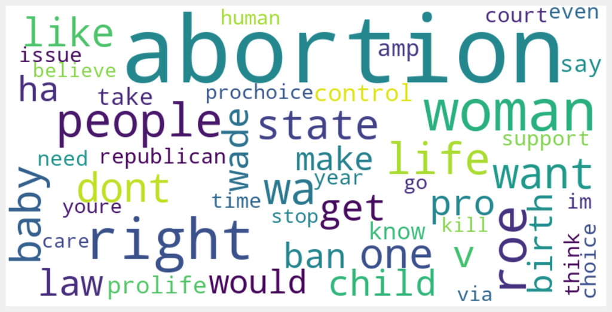

```python
from wordcloud import WordCloud

#stopwords = stop_words.extend(new_stop)
wc_leak = WordCloud(width=800, height=400, max_words=50, background_color="white", stopwords = stopwords).generate_from_frequencies(fdist)
plt.figure(figsize=(12,10))
plt.imshow(wc_leak, interpolation="bilinear")
plt.axis("off")
plt.show()
```

```python
fdist2 = FreqDist()
for tweet in official_frame_final['text']:
    for word in tweet:
        fdist2[word] += 1
fdist2
```

```
FreqDist({'abortion': 320, 'woman': 92, 'roe': 92, 'right': 86, 'state': 62, 'v': 60, 'wade': 58, 'people': 52, 'dont': 49, 'life': 48, ...})
```

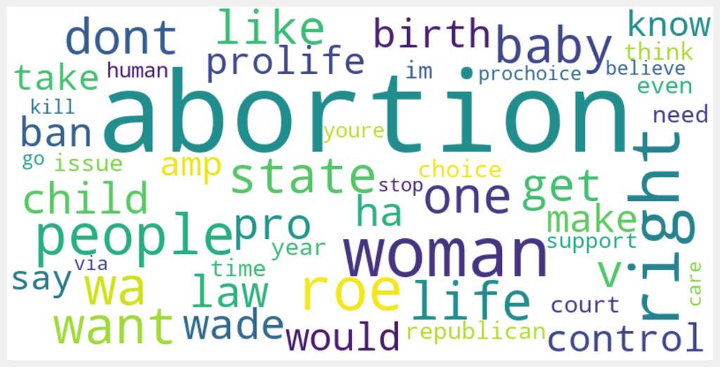

```python
wc_official = WordCloud(width=800, height=400, max_words=50, background_color="white").generate_from_frequencies(fdist)
plt.figure(figsize=(12,10))
plt.imshow(wc_official, interpolation="bilinear")
plt.axis("off")
plt.show()
```

```python
leak_frame_final['text'] = leak_frame_final['text'].astype(str)
```

```python
leak_frame_final['text']
```

```
0      ['pro', 'choice', 'pro', 'life', 'bro', 'im', ...
1      ['fetus', 'found', 'inside', 'dc', 'home', 'an...
2      ['fervent', 'wish', 'every', 'antiabortion', '...
3                     ['party', 'pro', 'life', 'strike']
4      ['vote', 'prolife', 'ni', 'assembly', 'electio...
                             ...
749    ['remember', 'gop', 'give', 'benefit', 'grandp...
750    ['democrat', 'prolife', 'party', 'trying', 'sa...
751    ['um', 'root', 'society', 'problem', 'cant', '...
752                                      ['like', 'roe']
753                                                   []
Name: text, Length: 754, dtype: object
```

```python
import string
import re
import nltk
string.punctuation
```

```
'!"#$%&\'()*+,-./:;<=>?@[\\]^_`{|}~'
```

```python
#defining the function to remove punctuation
def remove_punctuation(text):
    punctuationfree="".join([i for i in text if i not in string.punctuation])
    return punctuationfree

# remove punctuation, lowercase

leak_frame_final['clean_text']= leak_frame_final['text'].apply(lambda x:remove_punctuation(x))
leak_frame_final['clean_text']= leak_frame_final['clean_text'].apply(lambda x: x.lower())
```

```python
import textblob
from textblob import TextBlob
```

```python
def listToString(s):

    # initialize an empty string
    str1 = " "

    # return string
    return (str1.join(s))
```

```python
leak_frame_final['str_text'] = leak_frame_final['text'].apply(listToString)

corpus_leak = leak_frame_final['str_text']

corpus_df = pd.DataFrame(corpus_leak)
corpus_df.columns = ['tweet']
#corpus_df
corpus_df['polarity'] = corpus_df['tweet'].apply(lambda x: TextBlob(x).polarity)
corpus_df['subjective'] = corpus_df['tweet'].apply(lambda x: TextBlob(x).subjectivity)

corpus_df
```

|  | tweet | polarity | subjective |
| --- | --- | --- | --- |
| 0 | pro choice pro life bro im procreating ur mom | 0.000000 | 0.000000 |
| 1 | fetus found inside dc home antiabortion activist | 0.000000 | 0.000000 |
| 2 | fervent wish every antiabortion forced birth s... | -0.312500 | 0.562500 |
| 3 | party pro life strike | 0.000000 | 0.000000 |
| 4 | vote prolife ni assembly election th may via | 0.000000 | 0.000000 |
| ... | ... | ... | ... |
| 749 | remember gop give benefit grandparent mother d... | -0.283333 | 0.483333 |
| 750 | democrat prolife party trying save life yetunb... | -0.071429 | 0.214286 |
| 751 | um root society problem cant mind business ins... | 0.000000 | 0.000000 |
| 752 | like roe | 0.000000 | 0.000000 |
| 753 |  | 0.000000 | 0.000000 |

754 rows × 3 columns

```python
%%capture
pip install plotnine
```

```python
from pandas.api.types import CategoricalDtype
from plotnine import ggplot, aes, geom_line
from plotnine import *
from plotnine.data import mpg
%matplotlib inline
```

```python
from matplotlib.ticker import PercentFormatter
```

```python
plt.style.use('seaborn-paper')
```

```python
len(corpus_df['polarity'])
```

```
754
```

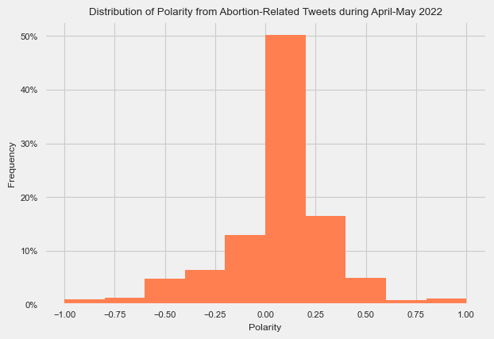

```python
plt.hist(corpus_df['polarity'], color='coral', weights=np.ones(len(corpus_df['polarity'])) / len(corpus_df['polarity']))
plt.gca().yaxis.set_major_formatter(PercentFormatter(1))
plt.xlabel("Polarity")
plt.ylabel("Frequency")
plt.title("Distribution of Polarity from Abortion-Related Tweets during April-May 2022")
plt.show()
```

```python
official_frame_final['str_text'] = official_frame_final['text'].apply(listToString)

corpus_off = official_frame_final['str_text']

corpus_df_off = pd.DataFrame(corpus_off)
corpus_df_off.columns = ['tweet']
#corpus_df
corpus_df_off['polarity'] = corpus_df_off['tweet'].apply(lambda x: TextBlob(x).polarity)
corpus_df_off['subjective'] = corpus_df_off['tweet'].apply(lambda x: TextBlob(x).subjectivity)

corpus_df_off
```

|  | tweet | polarity | subjective |
| --- | --- | --- | --- |
| 0 | abortion ban dont work abortion becomes danger... | -0.095238 | 0.403571 |
| 1 | disturbing libs dont care abortion mean reduci... | -0.190625 | 0.484375 |
| 2 | must secure abortion right | 0.342857 | 0.567857 |
| 3 | hey marcos rich baby killed year thank local d... | 0.058333 | 0.250000 |
| 4 | abortion gun biggest case biggest culture war ... | 0.000000 | 0.000000 |
| ... | ... | ... | ... |
| 443 | aoc rip justice alito alarming mockery figure ... | -0.100000 | 0.600000 |
| 444 | biden nominates abortion right lawyer federal ... | 0.285714 | 0.535714 |
| 445 | federal vaxx policy eliminates choice new fede... | -0.049784 | 0.508658 |
| 446 | wanting kill baby bad thing | -0.700000 | 0.666667 |
| 447 |  | 0.000000 | 0.000000 |

448 rows × 3 columns

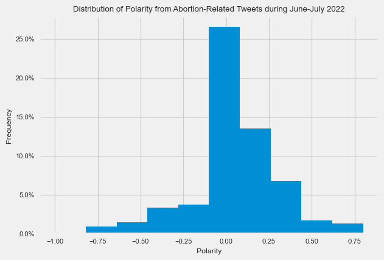

```python
plt.style.use('seaborn-paper')

plt.hist(corpus_df_off['polarity'], weights=np.ones(len(corpus_df_off['polarity'])) / len(corpus_df['polarity']))
plt.gca().yaxis.set_major_formatter(PercentFormatter(1))
plt.xlabel("Polarity")
plt.ylabel("Frequency")
plt.title("Distribution of Polarity from Abortion-Related Tweets during June-July 2022")
plt.show()
```

## 5. Statistical Tests

I want to run a series of multiple paired t-tests that compare pre- and post- Dobbs category frequencies and see if the difference is significant or not

```python
leak_df_test = leak_frame_final.iloc[:-1, :]
leak_df_test.tail()
```

|  | created_at | id | text | pro-life | pro-choice | neutral | directive | informative | emotional | political | ideological | anecdotal | ambiguous | irrelevant | just_date |
| --- | --- | --- | --- | --- | --- | --- | --- | --- | --- | --- | --- | --- | --- | --- | --- |
| 0 | 2022-04-01 00:15:40+00:00 | 1509685896488050688.0 | ['pro', 'choice', 'pro', 'life', 'bro', 'im', ... | 0.0 | 0.0 | 0.0 | 0.0 | 0.0 | 0.0 | 0.0 | 0.0 | 0.0 | 0.0 | 1.0 | 2022-04-01 00:00:00 |
| 1 | 2022-04-01 02:48:05+00:00 | 1509724250281807872.0 | ['fetus', 'found', 'inside', 'dc', 'home', 'an... | 0.0 | 0.0 | 1.0 | 0.0 | 1.0 | 0.0 | 0.0 | 0.0 | 0.0 | 0.0 | 0.0 | 2022-04-01 00:00:00 |
| 2 | 2022-04-01 04:42:39+00:00 | 1509753080908288000.0 | ['fervent', 'wish', 'every', 'antiabortion', '... | 0.0 | 1.0 | 0.0 | 0.0 | 0.0 | 1.0 | 0.0 | 0.0 | 0.0 | 0.0 | 0.0 | 2022-04-01 00:00:00 |
| 3 | 2022-04-01 10:47:35+00:00 | 1509844920533544704.0 | ['party', 'pro', 'life', 'strike'] | 0.0 | 1.0 | 0.0 | 0.0 | 0.0 | 0.0 | 1.0 | 0.0 | 0.0 | 0.0 | 0.0 | 2022-04-01 00:00:00 |
| 4 | 2022-04-01 12:10:49+00:00 | 1509865867353415680.0 | ['vote', 'prolife', 'ni', 'assembly', 'electio... | 1.0 | 0.0 | 0.0 | 1.0 | 0.0 | 0.0 | 1.0 | 0.0 | 0.0 | 0.0 | 0.0 | 2022-04-01 00:00:00 |
| ... | ... | ... | ... | ... | ... | ... | ... | ... | ... | ... | ... | ... | ... | ... | ... |
| 748 | 2022-05-30 19:12:01+00:00 | 1531352751925518336.0 | ['always', 'bring', 'abortion', 'conservative'... | 1.0 | 0.0 | 0.0 | 0.0 | 1.0 | 0.0 | 1.0 | 1.0 | 0.0 | 0.0 | 0.0 | 2022-05-30 00:00:00 |
| 749 | 2022-05-31 07:04:04+00:00 | 1531531944021721088.0 | ['remember', 'gop', 'give', 'benefit', 'grandp... | 0.0 | 1.0 | 0.0 | 1.0 | 0.0 | 1.0 | 1.0 | 0.0 | 0.0 | 0.0 | 0.0 | 2022-05-31 00:00:00 |
| 750 | 2022-05-31 15:52:08+00:00 | 1531664837104787456.0 | ['democrat', 'prolife', 'party', 'trying', 'sa... | 1.0 | 0.0 | 0.0 | 0.0 | 1.0 | 0.0 | 1.0 | 0.0 | 0.0 | 0.0 | 0.0 | 2022-05-31 00:00:00 |
| 751 | 2022-05-31 17:57:11+00:00 | 1531696306837667840.0 | ['um', 'root', 'society', 'problem', 'cant', '... | 0.0 | 1.0 | 0.0 | 0.0 | 0.0 | 1.0 | 0.0 | 1.0 | 0.0 | 0.0 | 0.0 | 2022-05-31 00:00:00 |
| 752 | 2022-05-31 23:00:04+00:00 | 1531772529936932864.0 | ['like', 'roe'] | 0.0 | 0.0 | 1.0 | 0.0 | 0.0 | 0.0 | 0.0 | 0.0 | 0.0 | 1.0 | 0.0 | 2022-05-31 00:00:00 |

753 rows × 15 columns

```python
leak_df_test.isnull().sum()
```

```
created_at     0
id             0
text           0
pro-life       2
pro-choice     2
neutral        2
directive      4
informative    6
emotional      3
political      5
ideological    6
anecdotal      5
ambiguous      4
irrelevant     5
just_date      0
dtype: int64
```

```python
official_df_test = official_frame_final.iloc[:-1, :]
official_df_test
```

|  | created_at | id | text | pro-life | pro-choice | neutral | directive | informative | emotional | political | ideological | anecdotal | ambiguous | irrelevant | just_date |
| --- | --- | --- | --- | --- | --- | --- | --- | --- | --- | --- | --- | --- | --- | --- | --- |
| 0 | 2022-06-01 11:17:42+00:00 | 1531958162185523200.0 | [abortion, ban, dont, work, abortion, becomes,... | 0.0 | 1.0 | 0.0 | 0.0 | 1.0 | 0.0 | 0.0 | 1.0 | 0.0 | 0.0 | 0.0 | 2022-06-01 00:00:00 |
| 1 | 2022-06-01 18:23:06+00:00 | 1532065213885083648.0 | [disturbing, libs, dont, care, abortion, mean,... | 1.0 | 0.0 | 0.0 | 0.0 | 1.0 | 1.0 | 1.0 | 0.0 | 0.0 | 0.0 | 0.0 | 2022-06-01 00:00:00 |
| 2 | 2022-06-01 19:09:46+00:00 | 1532076958334345216.0 | [must, secure, abortion, right] | 0.0 | 1.0 | 0.0 | 1.0 | 0.0 | 1.0 | 0.0 | 0.0 | 0.0 | 0.0 | 0.0 | 2022-06-01 00:00:00 |
| 3 | 2022-06-02 03:07:39+00:00 | 1532197221461946368.0 | [hey, marcos, rich, baby, killed, year, thank,... | 1.0 | 0.0 | 0.0 | 0.0 | 0.0 | 1.0 | 1.0 | 0.0 | 0.0 | 0.0 | 0.0 | 2022-06-02 00:00:00 |
| 4 | 2022-06-02 10:20:02+00:00 | 1532306035070861312.0 | [abortion, gun, biggest, case, biggest, cultur... | 0.0 | 0.0 | 1.0 | 0.0 | 1.0 | 0.0 | 0.0 | 1.0 | 0.0 | 0.0 | 0.0 | 2022-06-02 00:00:00 |
| ... | ... | ... | ... | ... | ... | ... | ... | ... | ... | ... | ... | ... | ... | ... | ... |
| 442 | 2022-07-29 10:52:28+00:00 | 1552970306238947328.0 | [people, told, truth, wrong, prohibit, abortio... | 0.0 | 1.0 | 0.0 | 0.0 | 0.0 | 0.0 | 0.0 | 1.0 | 0.0 | 0.0 | 0.0 | 2022-07-29 00:00:00 |
| 443 | 2022-07-29 15:16:51+00:00 | 1553036842416480256.0 | [aoc, rip, justice, alito, alarming, mockery, ... | 0.0 | 0.0 | 1.0 | 0.0 | 1.0 | 0.0 | 1.0 | 0.0 | 0.0 | 0.0 | 0.0 | 2022-07-29 00:00:00 |
| 444 | 2022-07-29 16:59:04+00:00 | 1553062563218264064.0 | [biden, nominates, abortion, right, lawyer, fe... | 0.0 | 0.0 | 1.0 | 0.0 | 1.0 | 0.0 | 1.0 | 0.0 | 0.0 | 1.0 | 0.0 | 2022-07-29 00:00:00 |
| 445 | 2022-07-29 19:17:51+00:00 | 1553097488998969088.0 | [federal, vaxx, policy, eliminates, choice, ne... | 0.0 | 0.0 | 1.0 | 0.0 | 0.0 | 0.0 | 0.0 | 1.0 | 0.0 | 0.0 | 0.0 | 2022-07-29 00:00:00 |
| 446 | 2022-07-30 03:45:52+00:00 | 1553225335629647872.0 | [wanting, kill, baby, bad, thing] | 1.0 | 0.0 | 0.0 | 0.0 | 0.0 | 1.0 | 0.0 | 1.0 | 0.0 | 0.0 | 0.0 | 2022-07-30 00:00:00 |

447 rows × 15 columns

```python
official_df_test.isnull().sum()
```

```
created_at     0
id             0
text           0
pro-life       3
pro-choice     4
neutral        3
directive      3
informative    3
emotional      3
political      3
ideological    4
anecdotal      3
ambiguous      3
irrelevant     5
just_date      0
dtype: int64
```

### Comparing pro-life and pro-choice for the month before and of the Politico leak vs the month of and after the Dobbs decision

**Pair 1: Pro-life (Apr-May) vs Pro-life (Jun-Jul)**

Null hypothesis: There is no difference between the frequency of pro-life tweets between April-May and June-July of 2022.

```python
from scipy import stats
```

```python
stats.ttest_rel(leak_df_test['pro-life'], official_df_test['pro-life'])
```

[output not shown]

I wanted to originally conduct a hypothesis test but there were issues with missing data and the fact that the sample sizes are not equal. April-May has 753 tweets and June-July has 447.

I then also attempted to run a chi-squared test to see if pro-life vs pro-choice are independent from emotional tweets

```python
from scipy.stats import chi2_contingency
```

**Pro-life association with emotional tweets during Politico leak**

```python
contingency = pd.crosstab(leak_frame['pro-life'], leak_frame['emotional'])
contingency
c, p, dof, expected = chi2_contingency(contingency)
p
```

```
0.029054233036183
```

**Pro-choice association with emotional tweets during Politico leak**

```python
contingency2 = pd.crosstab(leak_frame['pro-choice'], leak_frame['emotional'])
contingency2
c2, p2, dof2, expected2 = chi2_contingency(contingency2)
p2
```

```
1.8892566601710388e-09
```

**Pro-life association with emotional tweets during Dobbs period**

```python
contingency3 = pd.crosstab(official_frame['pro-life'], official_frame['emotional'])
contingency3
c3, p3, dof3, expected3 = chi2_contingency(contingency3)
p3
```

```
0.001232875725321124
```

**Pro-choice association with emotional tweets during Dobbs period**

```python
contingency4 = pd.crosstab(official_frame['pro-choice'], official_frame['emotional'])
contingency4
c4, p4, dof4, expected4 = chi2_contingency(contingency4)
p4
```

```
3.0022898798889277e-07
```

The p-values for the Chi-squared tests comparing pro-choice and emotion are much, much lower than the p-values for comparing pro-life with emotions. We reject the null that there is no relationship between these categorical variables. These data suggest there is a statistically significant association between abortion stance and whether or not their tweet expresses emotion.